# ProcB-resub

2025-07-31

Adressing the comments left by reviewer 2 on the ProcB submission:

Our time series look like this:

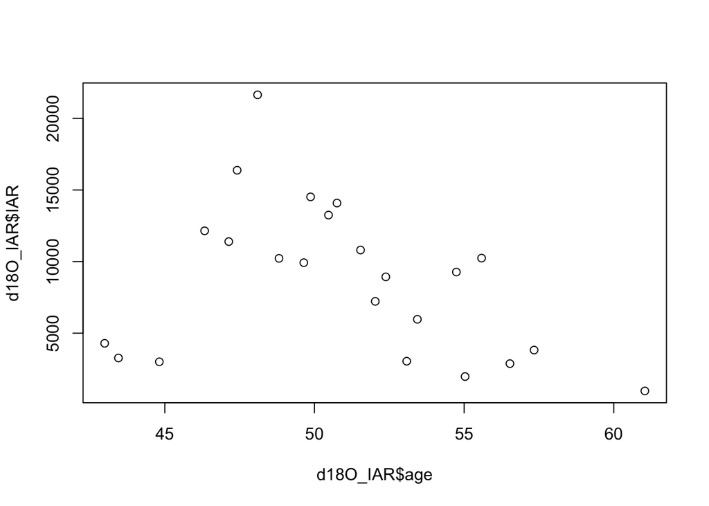

```r
plot(d18O_IAR$age, d18O_IAR$IAR)
```

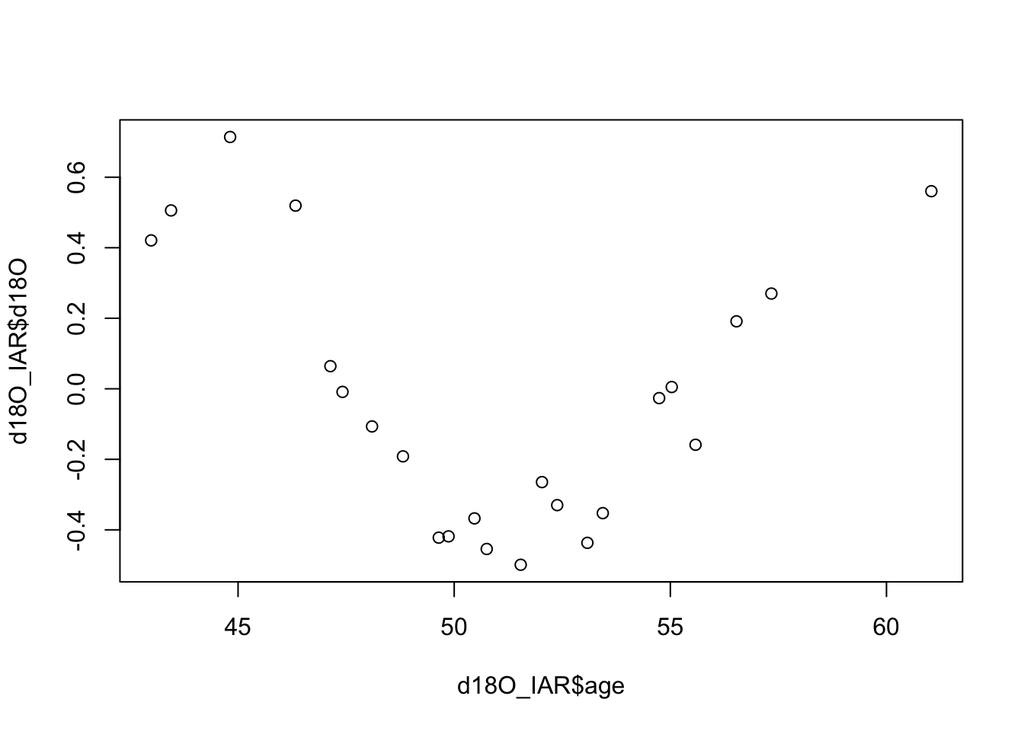

```r
plot(d18O_IAR$age, d18O_IAR$d18O)
```

And the correlation:

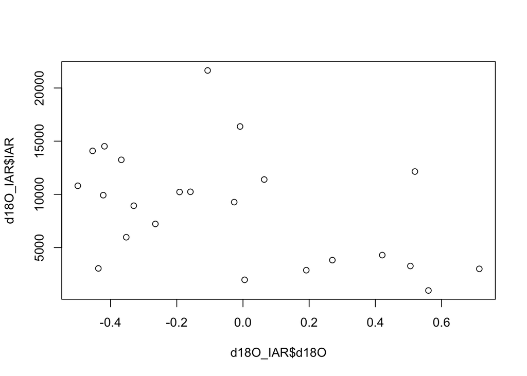

```r
plot(d18O_IAR$IAR ~ d18O_IAR$d18O)
```

```r
summary(lm(d18O_IAR$IAR ~ d18O_IAR$d18O))
```

```
##
## Call:
## lm(formula = d18O_IAR$IAR ~ d18O_IAR$d18O)
##
## Residuals:
##     Min      1Q  Median      3Q     Max
## -8186.7 -2906.4  -894.8  2604.6 12520.8
##
## Coefficients:
##               Estimate Std. Error t value Pr(>|t|)
## (Intercept)       8445       1021    8.27 4.81e-08 ***
## d18O_IAR$d18O    -6371       2758   -2.31   0.0312 *
## ---
## Signif. codes:  0 '***' 0.001 '**' 0.01 '*' 0.05 '.' 0.1 ' ' 1
##
## Residual standard error: 4876 on 21 degrees of freedom
## Multiple R-squared:  0.2026, Adjusted R-squared:  0.1646
## F-statistic: 5.335 on 1 and 21 DF,  p-value: 0.03116
```

We can check for non-stationarity with the Augmented Dickey-Fuller test. For the IAR dataset:

```r
print(tseries::adf.test(d18O_IAR$IAR))
```

```
##
##  Augmented Dickey-Fuller Test
##
## data:  d18O_IAR$IAR
## Dickey-Fuller = -3.4453, Lag order = 2, p-value = 0.07148
## alternative hypothesis: stationary
```

The P-value is too high to reject the null-hypothesis and there also seems to be a pattern in the autocorrelation factor:

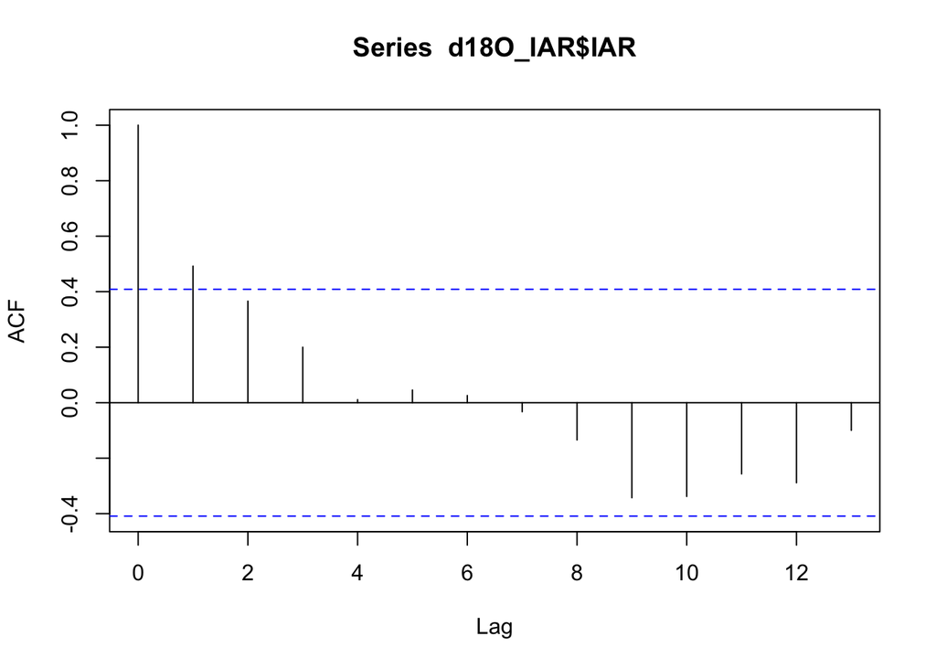

```r
acf(d18O_IAR$IAR)
```

Currently we are detrending by computing the residuals for each variable and then correlating. This does improve autocor. and non-stationary, as well as strengthen the correlation:

```r
model.iar <- lm(d18O_IAR$IAR ~ d18O_IAR$age)
model.d18 <- lm(d18O_IAR$d18O ~ d18O_IAR$age)

# Detrended series
model.iar <- residuals(model.iar)
model.d18 <- residuals(model.d18)

print(tseries::adf.test(model.iar))
```

```
##
##  Augmented Dickey-Fuller Test
##
## data:  model.iar
## Dickey-Fuller = -3.6066, Lag order = 2, p-value = 0.04953
## alternative hypothesis: stationary
```

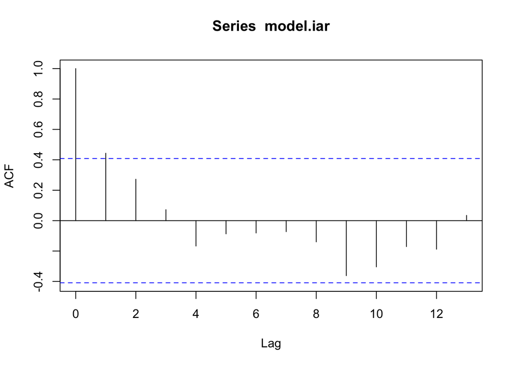

```r
acf(model.iar)
```

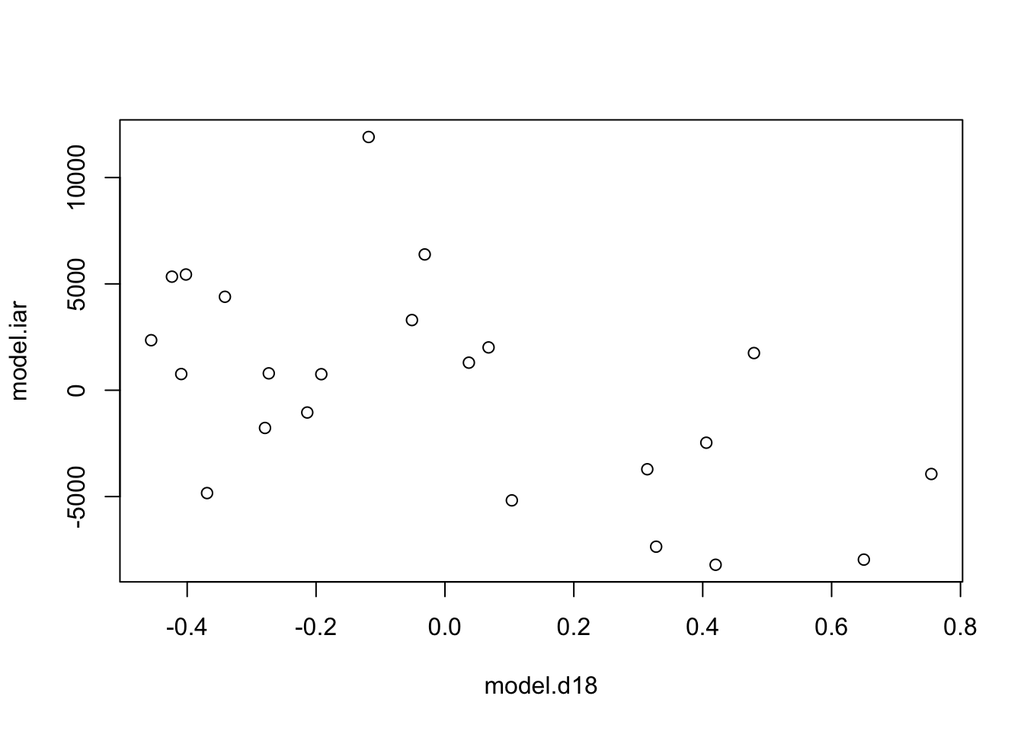

```r
plot(model.iar ~ model.d18)
```

```r
summary(lm(model.iar ~ model.d18))
```

```
##
## Call:
## lm(formula = model.iar ~ model.d18)
##
## Residuals:
##     Min      1Q  Median      3Q     Max
## -7617.2 -2862.0  -691.4  2280.6 11015.0
##
## Coefficients:
##               Estimate Std. Error t value Pr(>|t|)
## (Intercept) -6.259e-14  8.997e+02   0.000   1.0000
## model.d18   -7.534e+03  2.488e+03  -3.028   0.0064 **
## ---
## Signif. codes:  0 '***' 0.001 '**' 0.01 '*' 0.05 '.' 0.1 ' ' 1
##
## Residual standard error: 4315 on 21 degrees of freedom
## Multiple R-squared:  0.3039, Adjusted R-squared:  0.2708
## F-statistic: 9.169 on 1 and 21 DF,  p-value: 0.006399
```

First differences doesn’t appear to be so effective:

```r
## compute for diff time series
print(tseries::adf.test(diff(d18O_IAR$IAR))) #p-value increases
```

```
##
##  Augmented Dickey-Fuller Test
##
## data:  diff(d18O_IAR$IAR)
## Dickey-Fuller = -2.4424, Lag order = 2, p-value = 0.4038
## alternative hypothesis: stationary
```

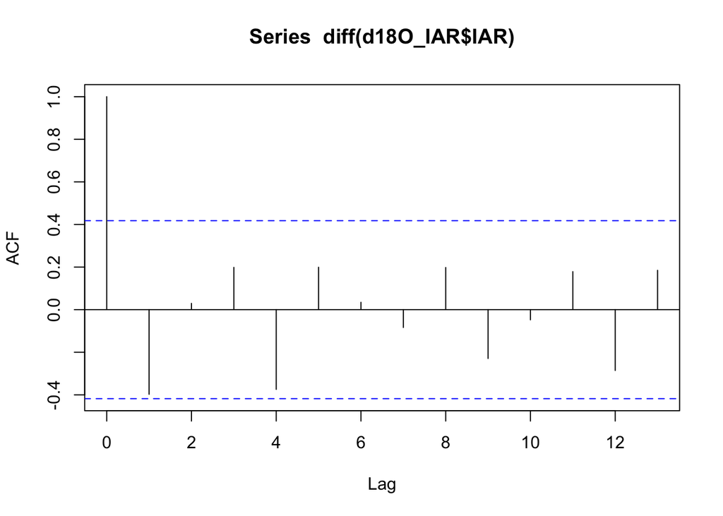

```r
acf(diff(d18O_IAR$IAR)) #acf looks better
```

And when we compute the correlation on the diff-series:

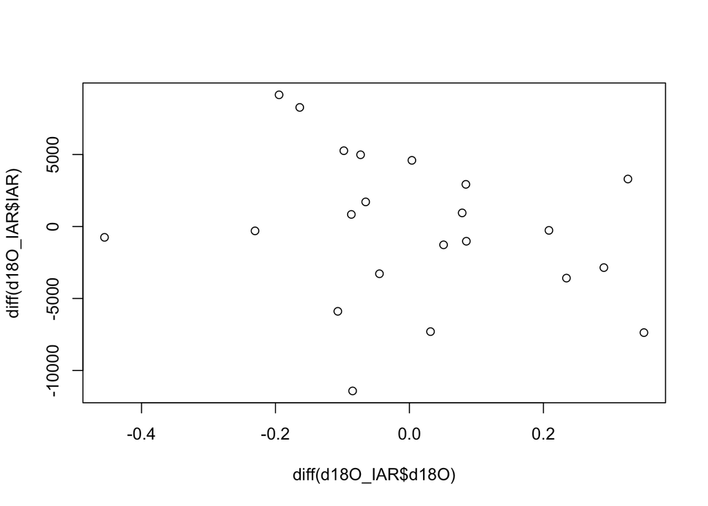

```r
plot(diff(d18O_IAR$IAR) ~ diff(d18O_IAR$d18O))
```

```r
summary(lm(diff(d18O_IAR$IAR) ~ diff(d18O_IAR$d18O)))
```

```
##
## Call:
## lm(formula = diff(d18O_IAR$IAR) ~ diff(d18O_IAR$d18O))
##
## Residuals:
##      Min       1Q   Median       3Q      Max
## -11867.0  -3083.2     12.4   4359.3   7981.0
##
## Coefficients:
##                     Estimate Std. Error t value Pr(>|t|)
## (Intercept)           -109.6     1090.3  -0.100    0.921
## diff(d18O_IAR$d18O)  -6555.0     5689.2  -1.152    0.263
##
## Residual standard error: 5111 on 20 degrees of freedom
## Multiple R-squared:  0.06224,    Adjusted R-squared:  0.01536
## F-statistic: 1.328 on 1 and 20 DF,  p-value: 0.2628
```

2nd differences didn’t improve anything much more.

I think the main reason 1st and 2nd differences fail is because the time points we are based our time series on are unevenly spaced, and evenly spaced observations are an assumption of 1st differences. Because this is the inevitable outcome of using an age-model like we are, I’m not sure there is much we can do. I’ll note this in the response to reviewers and probably make a note of it in the manuscript as well.

R2 also wanted us to run a GAM on the log-transformed length dataset.

Here is the GAM currently being used in the paper:

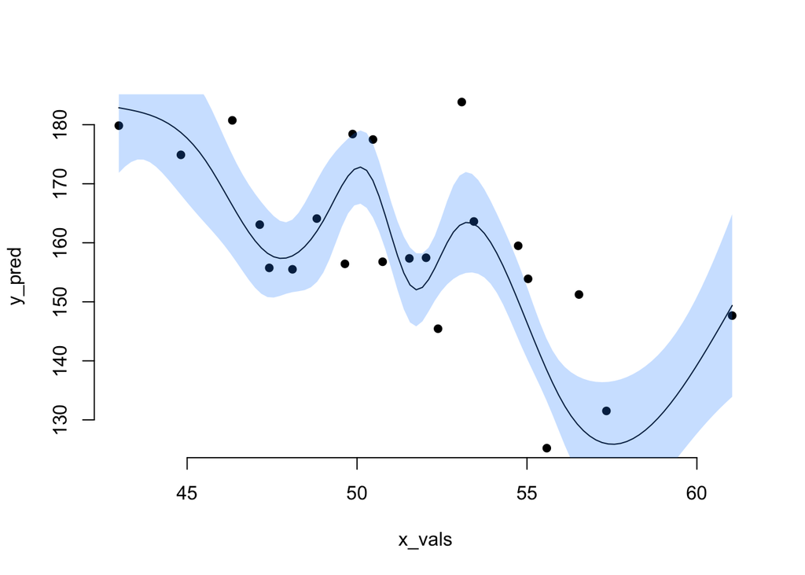

```r
yaxis.age <- rev(round(age.range)) # c(63, 41)
axis.scale <- 1.5
text.scale <- 1
pt.scale <- 2
txt.line <- 3.1

gam <- gam(length~s(nieder_ages, k = 10, bs = 'cs'), data=teeth_total)

x_vals <- seq(min(teeth_total$nieder_ages), max(teeth_total$nieder_ages), length = 100)
new_data <- data.frame(nieder_ages = x_vals)
pred <- predict(gam_5, newdata = new_data, se.fit = TRUE)
y_pred <- pred$fit
se <- pred$se.fit

ci <- 1.96 * se  # Assuming a normal distribution, 1.96 corresponds to a 95% confidence level
lower <- y_pred - ci
upper <- y_pred + ci


plot(x_vals, y_pred, type = "l", bty = 'n')
points(length_stats$nieder_ages, length_stats$length_mean, pch = 16)
polygon(c(x_vals, rev(x_vals)), c(lower, rev(upper)), col=means.col, border = NA)
```

I think the article linked by R2 made some really good points about log-transforming the tooth measurements, and I think we should for our figures. As can be seen below, this doesn’t have any effect on our results (luckily).

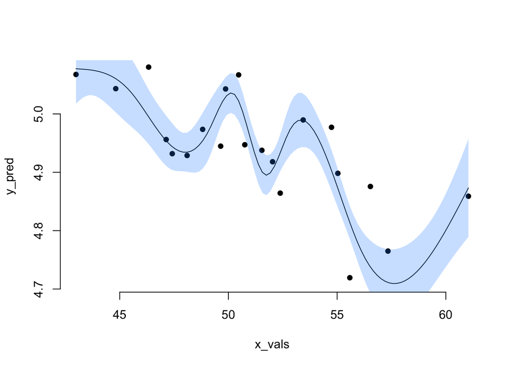

```r
axis.age <- rev(round(age.range)) # c(63, 41)
axis.scale <- 1.5
text.scale <- 1
pt.scale <- 2
txt.line <- 3.1

teeth_log <- teeth_total
teeth_log$log_length <- log(teeth_total$length)

gam_log <- gam(log_length~s(nieder_ages, k = 10, bs = 'cs'), data = teeth_log)

x_vals <- seq(min(teeth_total$nieder_ages),
              max(teeth_total$nieder_ages), length = 100)
new_data <- data.frame(nieder_ages = x_vals)
pred <- predict(gam_log, newdata = new_data, se.fit = TRUE)
y_pred <- pred$fit
se <- pred$se.fit

ci <- 1.96 * se  # Assuming a normal distribution, 1.96 corresponds to a 95% confidence level
lower <- y_pred - ci
upper <- y_pred + ci


length_means <- aggregate(log(teeth_total$length), list(teeth_total$SampleID), FUN = mean)
# Sort to have ascending sample number
length_means <- length_means[sort(as.numeric(length_means$Group.1), index.return = TRUE)$ix,]


plot(x_vals, y_pred, type = "l", bty = 'n')
points(length_stats$nieder_ages, length_means$x, pch = 16)
polygon(c(x_vals, rev(x_vals)), c(lower, rev(upper)), col=means.col, border = NA)
```

Essentially, the error bars are tightened, but nothing else changes.